# Red wine dataset Anaysis by Rakesh

lets look on quality vs alcohol vs sulphate

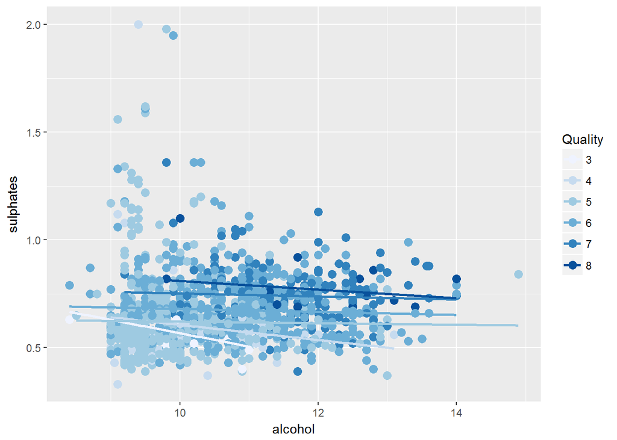

The above plot is can’t say like plot ,we cannot definately say with increase in alcohol and sulphate whether the quality will increase or not.

lets look on the considate view Alchol vs citric.acid vs sulphate vs quality.

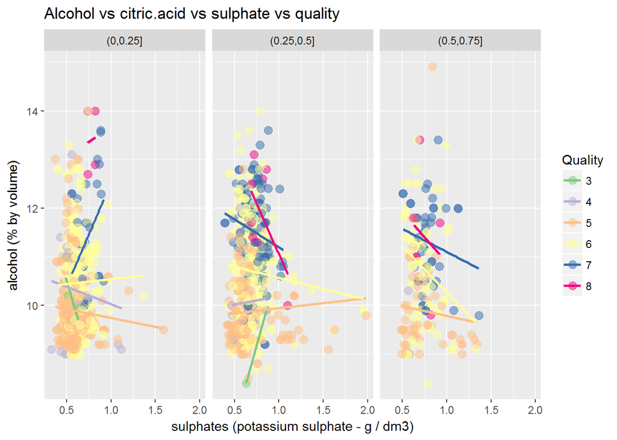

Now lets visiualize quality vs alcohol vs ph

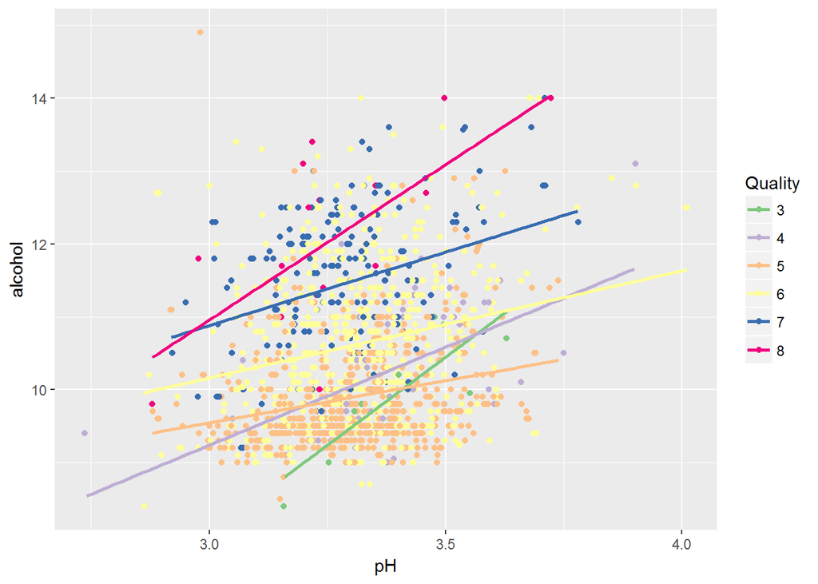

let view the above plot facet wise

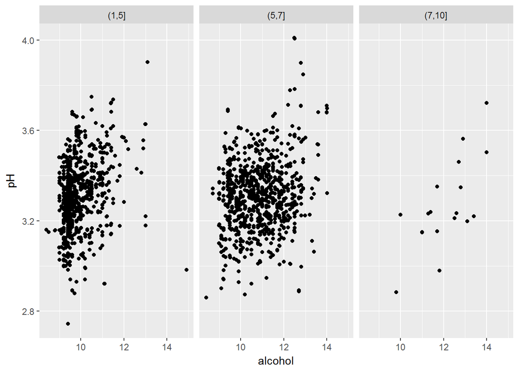

Now let look at negative co-related variable with quality.

quality vs alcohol vs volatile.acidity

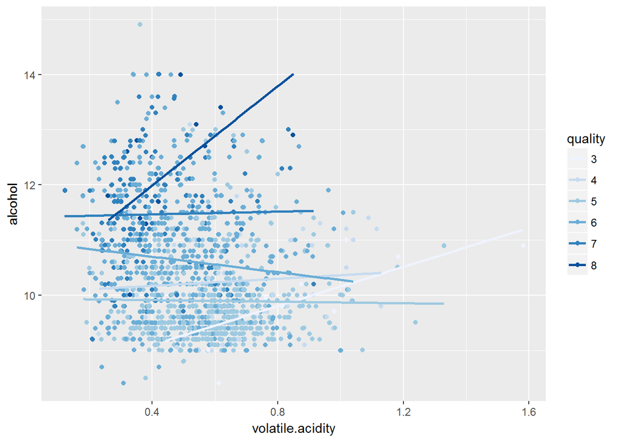

It seems that more the alcohol and less the volatile.acidity is more the quality of wine.

Now lets visiualize quality vs alcohol vs total.sulphur.dioxide.

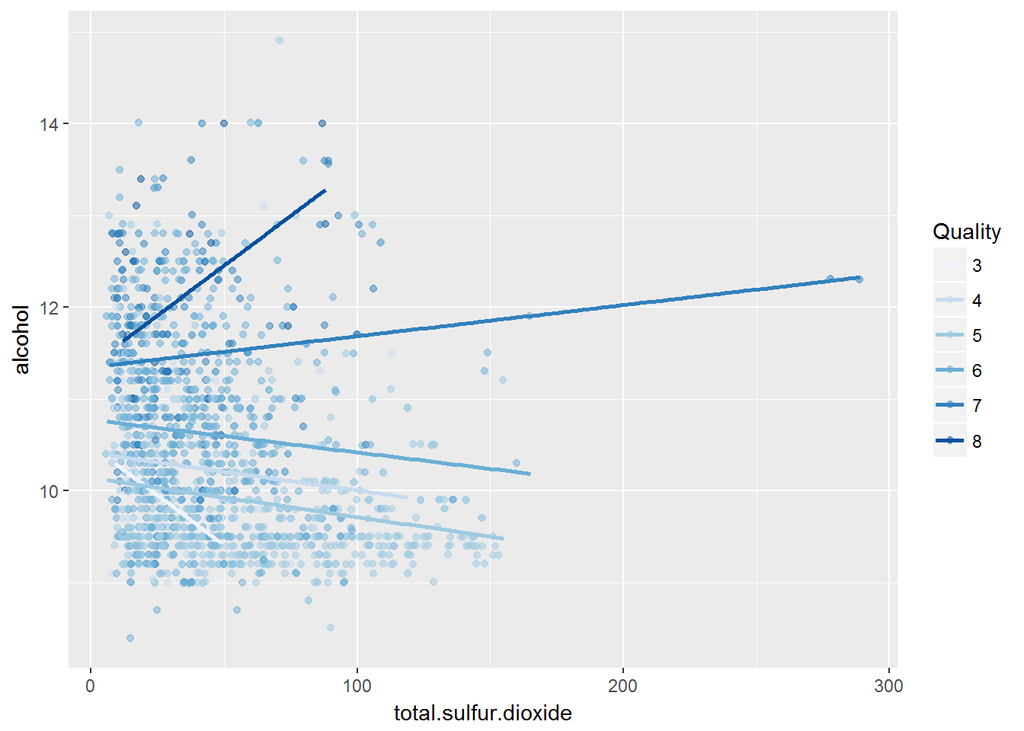

More the alcohol and less the total.sulfur.dioxide better the quality of wine is.

Next visiualisation is quality vs alcohol vs chlorides

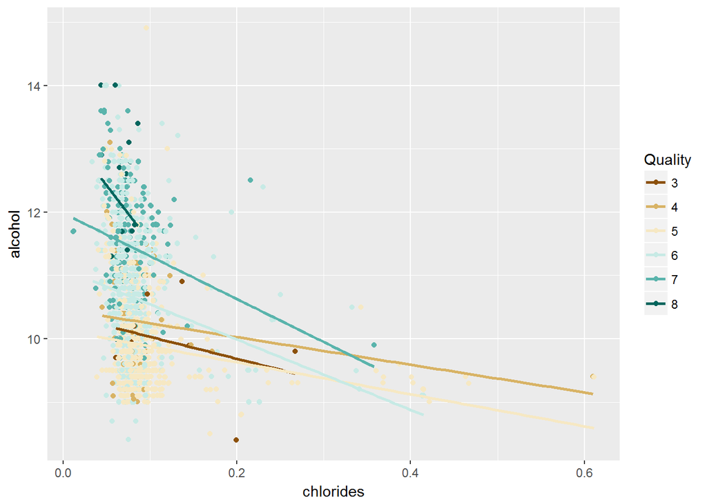

less the chloride better the quality of wine.

total.sulphur.dioxide vs chloride vs volatile.acidity vs quality.

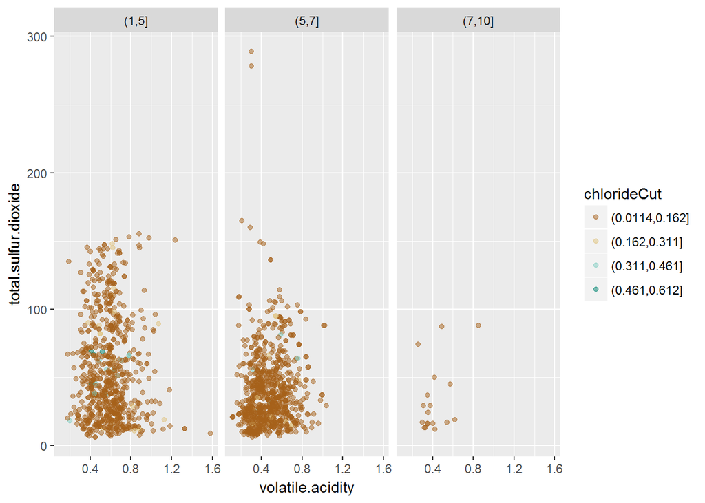

lesser the value of total.sulfur.dioxide,volatile.acidity and chlorideCut better the quality of wine.

lets plot the linear model for the positive correlated variable , negative correlated variables and alcohol.

```
##
## Calls:
## OnlyAlcohol: lm(formula = quality ~ alcohol, data = wineQualityDataset)
## positiveCorrelated: lm(formula = quality ~ alcohol + citric.acid + sulphates + fixed.acidity,
##     data = wineQualityDataset)
## negativeCorrelated: lm(formula = quality ~ total.sulfur.dioxide + volatile.acidity +
##     chlorides, data = wineQualityDataset)
## posandnegCorrelated: lm(formula = quality ~ alcohol + citric.acid + sulphates + fixed.acidity +
##     total.sulfur.dioxide + volatile.acidity + chlorides, data = wineQualityDataset)
##
## ==================================================================================================
##                         OnlyAlcohol  positiveCorrelated  negativeCorrelated  posandnegCorrelated
## --------------------------------------------------------------------------------------------------
##   (Intercept)             1.875***        1.138***            6.845***             2.652***
##                          (0.175)         (0.214)             (0.068)              (0.240)
##   alcohol                 0.361***        0.346***                                 0.288***
##                          (0.017)         (0.016)                                  (0.017)
##   citric.acid                             0.312*                                  -0.203
##                                          (0.125)                                  (0.145)
##   sulphates                               0.821***                                 0.888***
##                                          (0.106)                                  (0.111)
##   fixed.acidity                           0.033*                                   0.037**
##                                          (0.013)                                  (0.014)
##   total.sulfur.dioxide                                       -0.004***            -0.002***
##                                                              (0.001)              (0.001)
##   volatile.acidity                                           -1.682***            -1.173***
##                                                              (0.102)              (0.118)
##   chlorides                                                  -1.696***            -1.576***
##                                                              (0.389)              (0.408)
## --------------------------------------------------------------------------------------------------
##   R-squared                   0.2             0.3                 0.2                  0.4
##   adj. R-squared              0.2             0.3                 0.2                  0.4
##   sigma                       0.7             0.7                 0.7                  0.7
##   F                         468.3           159.8               121.9                124.9
##   p                           0.0             0.0                 0.0                  0.0
##   Log-likelihood          -1721.1         -1657.0             -1761.6              -1576.5
##   Deviance                  805.9           743.9               847.8                672.6
##   AIC                      3448.1          3326.1              3533.2               3171.1
##   BIC                      3464.2          3358.4              3560.1               3219.5
##   N                        1599            1599                1599                 1599
## ==================================================================================================
```

It is clearly visible that positive and negative correlated variable can explain the 40% of variance in quality , whereas only alcohol can explain only 20% and positive correlated variable can explain 30% of variance in quality.

# Multivariate Analysis

### Talk about some of the relationships you observed in this part of the

### investigation. Were there features that strengthened each other in terms of

### looking at your feature(s) of interest?

we have observed the following relationship

1. quality vs alcohol vs fixed acidity.
2. quality vs alcohol vs citric.acid.
3. quality vs alcohol vs sulphate.
4. quality vs alcohol vs volatile.acidity.
5. quality vs alcohol vs total.sulphur.dioxide.
6. quality vs alcohol vs chloride.
7. quality vs alcohol vs ph.
8. alchol vs citric.acid vs sulphate vs quality.
9. total.sulphur.dioxide vs chloride vs volatile.acidity vs quality.

### Were there any interesting or surprising interactions between features?

After looking the moderate(66%) correlation between alcohol and pH, i was expecting that with increase in alcohol and ph value the quality of wine will also increase. after visiualizing the different plot it is seems that quality of wine do increase with increase in alcohol and ph value but the relationship is not very linear.

### OPTIONAL: Did you create any models with your dataset? Discuss the

### strengths and limitations of your model.

Yes, I have have created models for the following relationship

1. quality vs alcohol explains (20% variance)
2. quality vs positive correlated variable (30% variance).
3. quality vs negative correlated variable (20% variance).
4. quality vs positive and negative correlated variable (40% variance).

Strength:positive and negative correlated variable give the clear picture how quality vary with most of dataset.

Weakness:There no as such linear one directional relationship in this model since we have included both positive and negative correlation.

# Final Plots and Summary

### Plot One

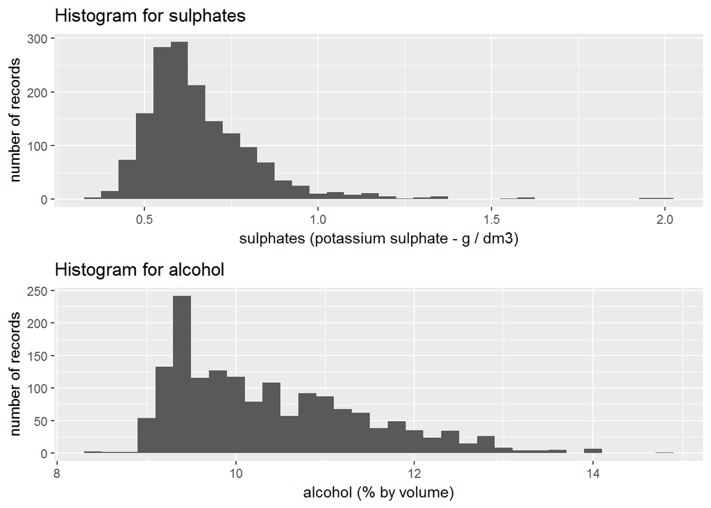

### Plot Two

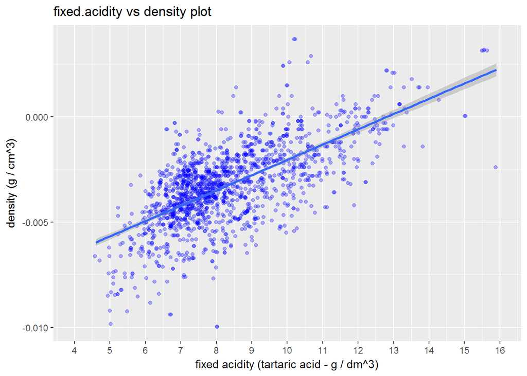

### Description Two

I have choose fixed.acidity vs density plot, this is only one plot which have very clear and linear relationship between two independent variable, and it also give some food for future analysis.

### Plot Three

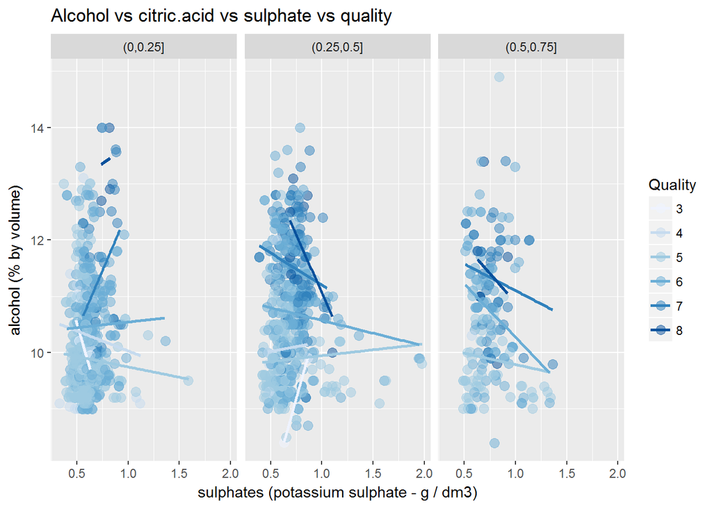

### Description Three

# Reflection

Red wine data set contains 1599 observation with 11 predictor variables and 1 responsive variable (quantity), we have found most of the predictior variable inclusive responsive variable are normally distributed.but there are some predictor variable are also present which are skewed in their data distribution , one of them is alcohol.

After analysing the frequency distribution of each variable. we moved to the bivariate analysis where i have choosed to analyze only those variable which are positively correlated with quality of wine(i haven’t found any strong correlation ,so i choosed to pick every positive correlation) for bivariate analysis. while carrying out the analysis i have discover that the negative correlated variables are also impacting the quality of wine.i also choosed to analyze two independent variable fixed.acidity and density and they were moderately correlated.this also give us way for the future work we can do on this data set.

At last we visualize the multivariate plots. we have visiualize all the positive correlated value with quality of wine and similarly we have also visualize the all the negative correlated value with the quality of wine that can explain 30 % and 20% of variance in the quality of wine respectively. we have also seen the linear model which shows the both positive and negative correlated values can explain more 40% variance in the quality of wine.

Ideas for future exploration: One of the idea that was clicked while carrying out red wine data analysis.Is to find the correlation between the independent variable. i have also explored the relationship between two independent variable ie. fixed.acidity and density and they were moderately correlation. i think we can find more such pair of independent variable and latter they can also contribute the defining quality of wine more precisely.